# Democracy around the world — a guide to the data

Diversity in a Globalized World

Published

September 9, 2026

# What this data is about

For most of the twentieth century, the story of democracy was a story of expansion. Countries that had never held free elections began holding them. That is no longer the story. Since roughly 2000, more countries have moved away from democracy than towards it — and this has happened not mainly through coups, but through elected governments gradually weakening the institutions that limit them.

Measuring this is harder than it sounds. “Is this country a democracy?” has no yes-or-no answer, and the interesting cases are exactly the ambiguous ones.

The **Varieties of Democracy** project takes a different approach. Rather than labelling countries, it asks thousands of country experts a long list of specific questions — are elections clean, can journalists publish freely, do courts constrain the president — and combines the answers into indices between 0 and 1.

**This folder contains those measures for 181 countries, 1990 to 2023.**

# The two files

| File | Use it for | What one row is |
| --- | --- | --- |
| `countries.rds` | **Maps** | One country |
| `democracy_panel.rds` | **Change over time** | One country, one year |

```r
library(sf)
library(ggplot2)

countries <- readRDS("preprocessed_data/countries.rds")
panel     <- readRDS("preprocessed_data/democracy_panel.rds")
```

# `countries.rds` — for maps

One row per country, with its shape attached, comparing **2000** with **2023**.

```r
countries |>
  st_drop_geometry() |>
  filter(iso3 %in% c("MEX","BRA","USA","HUN")) |>
  select(country, liberal_democracy_2000, liberal_democracy_now, democracy_change)
```

```
                   country liberal_democracy_2000 liberal_democracy_now
1 United States of America                  0.808                 0.789
2                   Mexico                  0.481                 0.302
3                  Hungary                  0.750                 0.323
4                   Brazil                  0.717                 0.695
  democracy_change
1           -0.019
2           -0.179
3           -0.427
4           -0.022
```

| Variable | What it means |
| --- | --- |
| `iso3`, `country`, `continent` | Country code, name, continent |
| `liberal_democracy_2000` / `_now` | Overall score in 2000 and 2023, from 0 to 1 |
| `democracy_change` | The difference. **Negative = democracy weakened** |
| `electoral_democracy_2000` / `_now` | Are elections free and fair? |
| `rule_of_law_2000` / `_now` | Do laws actually constrain those in power? |
| `civil_liberties_2000` / `_now` | Can people speak, gather and organise freely? |
| `geometry` | The country’s shape — you never touch this directly |

**A map takes one line.** Because this variable goes both up and down, use a scale with a meaningful middle:

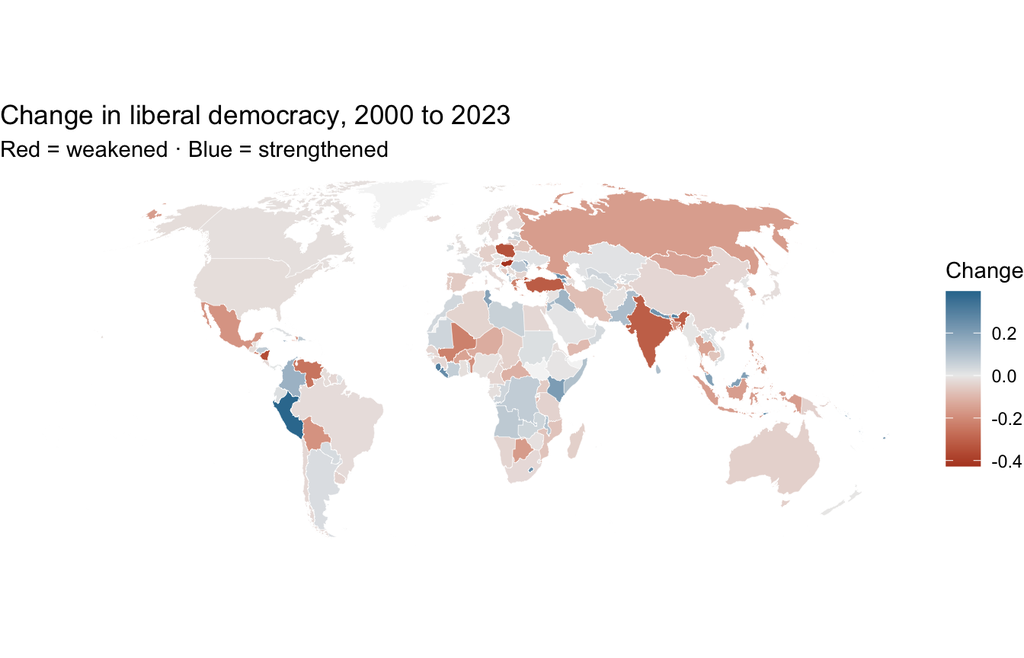

```r
ggplot(countries) +
  geom_sf(aes(fill = democracy_change), color = "white", linewidth = 0.1) +
  scale_fill_gradient2(low = "#b44527", mid = "grey92", high = "#0f6f96",
                       midpoint = 0, na.value = "grey96", name = "Change") +
  labs(title = "Change in liberal democracy, 2000 to 2023",
       subtitle = "Red = weakened · Blue = strengthened") +
  coord_sf(crs = "+proj=robin") +
  theme_void()
```

Most of the map is red. That is the finding, and it is why this session exists.

# `democracy_panel.rds` — for change over time

The same measures, but every year from 1990 to 2023. Use this when you want to see *when* something happened rather than just how much.

```r
head(panel[panel$iso3 == "MEX", c("country","year","liberal_democracy","rule_of_law")], 4)
```

```
  country year liberal_democracy rule_of_law
1  Mexico 1990             0.186       0.333
2  Mexico 1991             0.196       0.333
3  Mexico 1992             0.208       0.333
4  Mexico 1993             0.215       0.333
```

It also carries `participatory`, `freedom_expression`, `clean_elections`, `exec_constraints`, `media_censorship` and `opposition_autonomy`.

**A line for one country:**

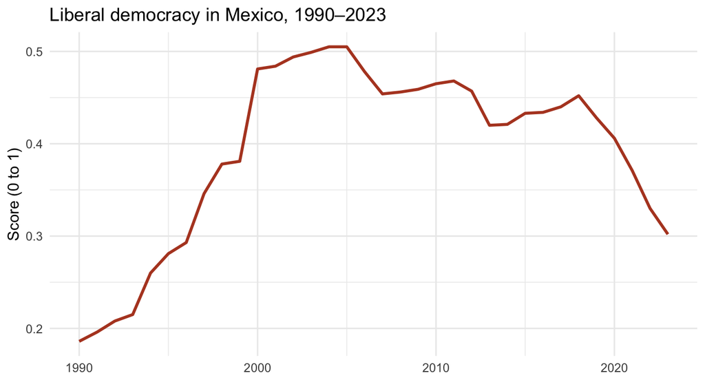

```r
mex <- panel[panel$iso3 == "MEX", ]

ggplot(mex, aes(year, liberal_democracy)) +
  geom_line(color = "#b44527", linewidth = 1) +
  labs(title = "Liberal democracy in Mexico, 1990–2023",
       x = NULL, y = "Score (0 to 1)") +
  theme_minimal()
```

# Start here: where does Mexico sit?

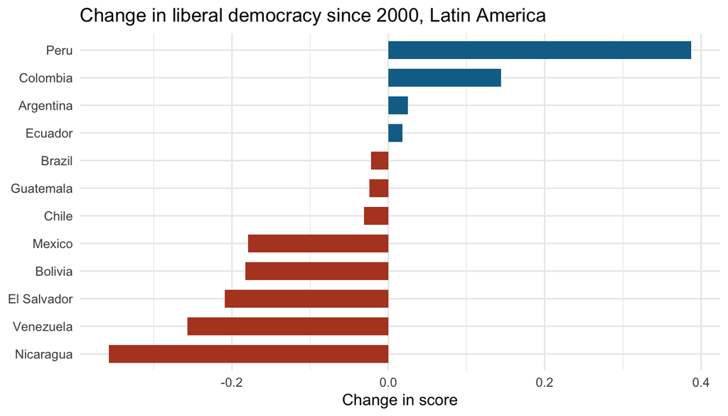

```r
lat <- c("MEX","BRA","ARG","COL","CHL","PER","VEN","BOL","ECU","SLV","NIC","GTM")

countries |>
  st_drop_geometry() |>
  filter(iso3 %in% lat) |>
  ggplot(aes(x = reorder(country, democracy_change), y = democracy_change)) +
  geom_col(aes(fill = democracy_change > 0), width = 0.65, show.legend = FALSE) +
  scale_fill_manual(values = c(`TRUE` = "#0f6f96", `FALSE` = "#b44527")) +
  coord_flip() +
  labs(title = "Change in liberal democracy since 2000, Latin America",
       x = NULL, y = "Change in score") +
  theme_minimal()
```

Mexico is among the larger declines in the region. But notice that the region does not move together: Peru and Colombia improved over the same years. Whatever is happening, it is not simply “Latin America”.

# What this data does and does not measure

**It measures democratic institutions, not populism.** This distinction matters and you should be careful with it.

There is no clean “populism score” here. What you have is whether courts constrain presidents, whether elections are clean, whether journalists can publish. Populism is often *argued* to cause those things to weaken — but the data shows the consequence, not the cause.

So a sentence like “populism is rising in Mexico” is **not** something you can support with this data. A sentence like “the institutions that constrain Mexican governments have weakened since 2000” is.

If you want to say something about populism itself, you would need a different source, and you should say so.

# Other things worth knowing

**Scores run from 0 to 1**, so changes look small. A move of 0.18 is large — it is roughly what Mexico did between 2000 and 2023.

**These are expert judgements, not counts.** V-Dem asks many country experts and combines their answers. That is more informative than a yes-or-no label, but it is still opinion, carefully collected. Experts can be wrong, and they can be wrong together.

**Use a diverging colour scale for change.** `scale_fill_gradient2()` with `midpoint = 0` puts grey at “no change”, so red and blue mean opposite directions. A normal scale would hide that.

**173 of 241 shapes have data.** Very small countries mostly do not appear.

# Questions you could ask

- Which regions declined most, and did neighbouring countries move together?
- Did the decline happen gradually or suddenly? Pick five countries and plot them over time with the panel file.
- Which fell first — clean elections, rule of law, or civil liberties? That ordering tells you *how* democracies weaken.
- Do countries that were more democratic in 2000 have more to lose, or are they more resilient?
- Where does Mexico’s decline sit in time? Does it line up with a change of government?
- Compare Latin America with Eastern Europe. Same pattern, or different?

# Where the data comes from

Varieties of Democracy (V-Dem) project, via the `vdemdata` R package. Country outlines from Natural Earth. We kept 1990 to 2023, selected ten indices, renamed them into plain English, and attached the map shapes.

V-Dem Institute, University of Gothenburg — https://v-dem.net